# ggpubr Tutorial

Shaurita D. Hutchins

2022-12-07

# Introduction

The `ggpubr` package is a useful tool for creating visualizations in R using the `ggplot2` package. It provides a number of functions for creating common plots such as scatter plots, box plots, and bar plots, and also includes functions for adding statistical tests and annotation to plots.

## Examples

Below are two examples.

## An Example MA Plot

The `ggmaplot` function from the `ggpubr` package is used to create an MA plot, which is a type of scatter plot used to visualize the results of a differential expression analysis. The `diff_express` data set is provided as input, and various arguments are passed to customize the plot, such as the main title, the false discovery rate, the fold change threshold, the color palette, and the font sizes and styles. The `annotate_figure` function is then used to add text annotation to the plot.

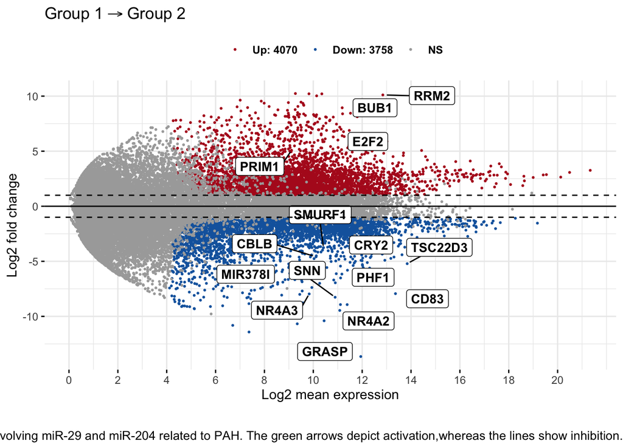

```r
data(diff_express)

# MA PLOT
maplot <- ggmaplot(diff_express, main = expression("Group 1" %->% "Group 2"),
         fdr = 0.05, fc = 2, size = 0.4,
         palette = c("#B31B21", "#1465AC", "darkgray"),
         genenames = as.vector(diff_express$name),
         legend = "top", top = 20,
         font.label = c("bold", 11), label.rectangle = TRUE,
         font.legend = "bold",
         font.main = "bold",
         ggtheme = ggplot2::theme_minimal())

txt <- "\nFigure 1. Networks representing known interactions involving miR-29 and miR-204 related to PAH. The green arrows depict activation,whereas the lines show inhibition."
x <- annotate_figure(maplot,
                bottom = text_grob(txt, color = "black",
                                   hjust = 1, x = 1,  size = 10))
x
```

```r
#ggexport(x, filename = "ma_example.png", width = 800)
```

## An Example Box Plot

The `ggboxplot` function is used to create a box plot using the `ToothGrowth` data set. The `dose` and `len` variables are specified as the x and y variables, respectively, and the `color`, `palette`, `add`, and `shape` arguments are used to customize the appearance of the plot. The `stat_compare_means` function is then used to add p-values for pairwise comparisons between the different groups and a global p-value to the plot. The `annotate_figure` function is used again to add a figure label to the plot.

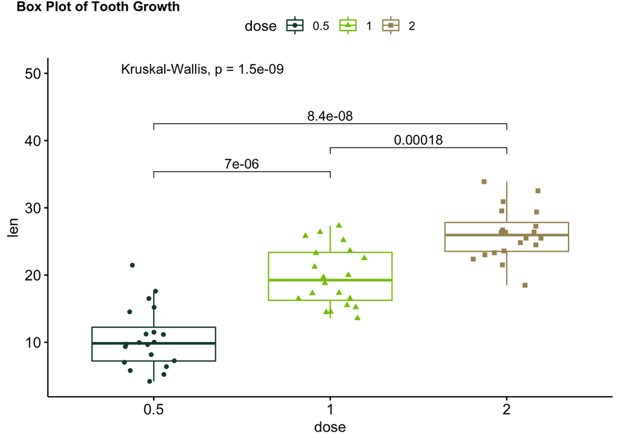

```r
# Load data
data("ToothGrowth")
df <- ToothGrowth
# Change outline colors by groups: dose
# Use custom color palette
# Add jitter points and change the shape by groups
p <- ggboxplot(df, x = "dose", y = "len",
               color = "dose", palette = c("#144B39", "#88C408", "#A69363"),
               add = "jitter", shape = "dose")
# Add p-values comparing groups
# Specify the comparisons you want
my_comparisons <- list( c("0.5", "1"), c("1", "2"), c("0.5", "2") )
bp <- p + stat_compare_means(comparisons = my_comparisons) + # Add pairwise comparisons p-value
  stat_compare_means(label.y = 50)                   # Add global p-value

y <- annotate_figure(bp, fig.lab = "Box Plot of Tooth Growth", fig.lab.pos = "top.left", fig.lab.face = "bold")
y
```

```r
#ggexport(y, filename = "box_example.png", width = 800)
```